# dualGSEA: example run!

Sudhir B. Malla

2024-10-25

## Example run of *dualGSEA()* function

### Installation R packages

Below are the list of R packages required for the *dualGSEA()* function to run. *cowplot* and *reactable* are used here for documentation purpose and are not necessary to run the function.

```r
## List of packages
bio_pkgs <- c("limma", "msigdbr", "DOSE", "devtools","fgsea", "enrichplot","GSVA","circlize",
              "ComplexHeatmap","ggridges","pROC","cutpointr","ggalluvial","waterfalls",
              "randomForest","devtools","tibble","msigdbr","data.table","tidyverse","dplyr",
              "ggplot2","grid","gridExtra","ROCR","reshape2","stats","RColorBrewer","ggpubr",
              "ggbeeswarm","tidyr","caret","escape", "doRNG")
github_pkgs <- c("kassambara/easyGgplot2")


## If not already installed
# suppressMessages({
#   if (!require(bio_pkgs, quietly = TRUE))
#     BiocManager::install(bio_pkgs)
#   if (!require(github_pkgs, quietly = TRUE))
#     devtools::install_github(github_pkgs, dependencies = TRUE, force=TRUE)
# })


## Load R packages
suppressPackageStartupMessages(suppressMessages(
  lapply(bio_pkgs, library, character.only = TRUE)
))
suppressPackageStartupMessages(suppressMessages(
  library(easyGgplot2)
))

## Extra packages to run example
# BiocManager::install("cowplot")
library(cowplot)
# BiocManager::install("reactable")
library(reactable)
```

### Import example data

The *dualGSEA()* function requires three inputs (1. *gene expression data*, 2. *group labels*, 3. *geneset list*). This example provided here is the subset of the data from [Kennedy *et al.*, JCO, 2011](https://doi.org/10.1200/jco.2011.35.4498), originally consisting of n=215 stage II primary tumours from colon cancer patients. PDSclassifier was used on the whole dataset (n=215; [E-MTAB-863](https://www.ebi.ac.uk/biostudies/arrayexpress/studies/E-MTAB-864)) prior to subsetting into PDS1 and PDS3 samples for the example run below. The list of gene signature was downloaded directly from the Molecular Signature Database (MSigDB) via *msigdbr* R package. Here, we use the **“Hallmark”** collection (n=50).  
**NOTE**: In the study (Bull *et al.*,), Figure 4 was NOT generated using *dualGSEA()* but rather generated separately. You may find slight variation between the Figure 4 and results generated here due to, 1. geneset from MSigDB which may differ due to different version of *msigdbr* used, 2. **normalised ssGSEA** score also differ slightly due to subsetting the dataset.

```r
## example gene expression data
exp_data_filenm <- "example_expression_data.txt"
exp_data_filepath <- here::here("data/example_run", exp_data_filenm)
exp_data <- read.delim(exp_data_filepath, header = T, stringsAsFactors = F)

head(exp_data[1:5])
```

```
##         R01251005N R0125F008N R0125F011R R0125F013R R0125F020N
## A1CF       6.95677    8.07285    6.79073    6.28439    8.22720
## A2M        5.26289    5.48732    5.65054    5.87608    6.22522
## A2M.AS1    1.62406    1.71402    2.45270    2.26668    2.31935
## A2ML1      4.11164    4.86334    4.61440    4.20542    5.34338
## A4GALT     6.66301    6.78074    6.78218    6.46541    8.64069
## AAAS       3.98025    4.25351    5.22548    4.79598    4.80062
```

```r
## example sample labels data
label_data_filenm <- "example_labels.txt"
label_data_filepath <- here::here("data/example_run", label_data_filenm)
label_data <- read.delim(label_data_filepath, header = T, stringsAsFactors = F)

head(label_data)
```

```
##             Sample_ID PDS_call
## R01251005N R01251005N     PDS1
## R0125F008N R0125F008N     PDS1
## R0125F011R R0125F011R     PDS3
## R0125F013R R0125F013R     PDS3
## R0125F020N R0125F020N     PDS3
## R0125F043N R0125F043N     PDS3
```

```r
## making sure the sample are aligned between the two data
#all(colnames(exp_data) == label_data$Sample_ID)


## Lastly, geneset list - we will use MSigDB to extract Hallmark collection for this example.
geneset1 <- msigdbr::msigdbr(category = "H")
geneset_list <- geneset1 %>% split(f = .$gs_name, x = .$human_gene_symbol)
```

### Running *dualGSEA*

To run *dualGSEA*, please download and run the function. Make sure the input data are as instructed.

```r
## Get dualGSEA() function
dualgsea_fun_file <- here::here("function", "dualGSEA.R")
source(dualgsea_fun_file)


## Run dualGSEA
## NOTE: invisible() and capture.output() is being used here to hide messages and progressbar
## that would be shown in the document otherwise.
set.seed(127)
invisible(capture.output(

  res1 <- dualGSEA(data = exp_data,
                 group_data = label_data,
                 group_colname = "PDS_call",
                 geneset_list = geneset_list)

  ))

## Outputs in a list
names(res1)
```

```
##  [1] "Differential_GeneRanking"          "Pairwise_ResultTable"
##  [3] "Pairwise_BarPlot"                  "Pairwise_EnrichmentPlots"
##  [5] "SingleSample_ResultTable"          "SingleSample_DensityPlots"
##  [7] "SingleSample_Histograms"           "SingleSample_ROCPlots"
##  [9] "SingleSample_OptimumCutoff_Labels" "SingleSample_WaterfallPlots"
```

```r
## save as rds
# saveRDS(res1,
#         file = here::here("data/example_run/example_result", "example_result_obj.rds")
#           )
```

### Outputs:

In this example, the *dualGSEA* outputs list containing plots associated with all n=50 Hallmark gene signature. However, for the purpose of the documentation, visual figures only for **“HALLMARK_MYC_TARGETS_V1”** geneset will be displayed.

#### 1. Differential Gene Ranking:

```r
## showing top 5 rows
reactable(head(res1[["Differential_GeneRanking"]])[1:5,])
```

| symbol | logFC | AveExpr | t | P.Value | adj.P.Val | B | combined_value |
| --- | --- | --- | --- | --- | --- | --- | --- |
| NCL | 1.741327997151 | 6.22830352941176 | 13.7682871445523 | 1.62814902606956e-26 | 2.0044255327899e-22 | 49.6807866567682 | 44.9058989691324 |
| FOXP2 | -0.783611880341882 | 9.34352218487395 | -13.6850805260672 | 2.54967313208663e-26 | 2.0044255327899e-22 | 49.2405788249152 | -20.0553827996519 |
| MCM6 | 1.53848043589743 | 5.03833521008403 | 13.2839313845456 | 2.23492452769447e-25 | 9.13872209793511e-22 | 47.1094060946446 | 37.924676817565 |
| HSPE1 | 1.46964047293447 | 7.70271890756303 | 13.2766582830123 | 2.32493089052601e-25 | 9.13872209793511e-22 | 47.0706359531606 | 36.202520787358 |
| SLBP | 1.27144976923077 | 6.3881356302521 | 13.1619526856836 | 4.33595648564613e-25 | 1.36348487647628e-21 | 46.4585962971335 | 30.9762227624805 |

#### 2. Pairwise GSEA Result (Table):

```r
## showing top 5 row. Leading edge gene column removed from display.
reactable(head(res1[["Pairwise_ResultTable"]])[1:5,1:6])
```

| pathway | pval | padj | log2err | ES | NES |
| --- | --- | --- | --- | --- | --- |
| HALLMARK_ADIPOGENESIS | 2.75583626835586e-05 | 0.000125265284925267 | 0.575610261071129 | 0.324620876687494 | 1.76393381761324 |
| HALLMARK_ALLOGRAFT_REJECTION | 0.972602739726027 | 1 | 0.0725351864394589 | 0.146624748133724 | 0.79009103173393 |
| HALLMARK_ANDROGEN_RESPONSE | 0.000540193767182132 | 0.00180064589060711 | 0.477270815362862 | 0.35546766847015 | 1.74836129413016 |
| HALLMARK_ANGIOGENESIS | 0.6575 | 0.809822361546499 | 0.0764767053228531 | 0.224957885759072 | 0.875950476033585 |
| HALLMARK_APICAL_JUNCTION | 0.277392510402219 | 0.407930162356205 | 0.0913924325943768 | -0.224424257358731 | -1.09550106233598 |

#### 3. Pairwise GSEA Barplot:

The output consists of barplot that displays the significantly upregulated or downregulated geneset between the two comparable groups.

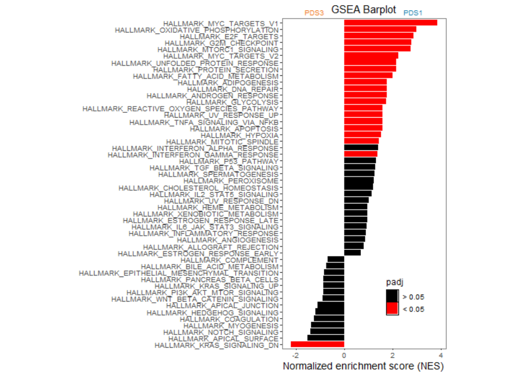

```r
ggdraw() +
  draw_image(here::here("data/example_run/example_result", "output3.png"))
```

#### 4. Pairwise Enrichment:

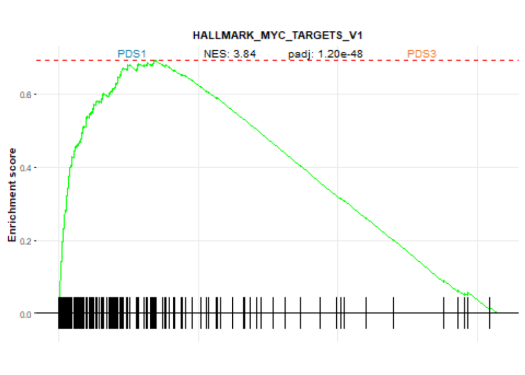

```r
ggdraw() +
  draw_image(here::here("data/example_run/example_result", "output4.png"))
```

#### 5. Single sample GSEA Result (Table):

```r
reactable(head(res1[["SingleSample_ResultTable"]])[1:5,1:6])
```

| ID | HALLMARK_ADIPOGENESIS | HALLMARK_ALLOGRAFT_REJECTION | HALLMARK_ANDROGEN_RESPONSE | HALLMARK_ANGIOGENESIS | HALLMARK_APICAL_JUNCTION |
| --- | --- | --- | --- | --- | --- |
| R01251005N | 0.341665192107925 | 0.164405693982836 | 0.446245958183828 | 0.406503552654269 | 0.310303384197391 |
| R0125F008N | 0.298479418235461 | 0.130625160855525 | 0.490215377652068 | 0.504437604409936 | 0.321347935958017 |
| R0125F052N | 0.324733438945314 | 0.154893585679824 | 0.454060951008825 | 0.459178068859171 | 0.31526616499444 |
| R0125F054N | 0.32877147956877 | 0.148372840485972 | 0.420797258192364 | 0.531977221402461 | 0.344844511316976 |
| R0125F062N | 0.301090558536486 | 0.11742882167706 | 0.44060777650496 | 0.354193422789394 | 0.281428852423529 |

#### 6. Single sample GSEA Density plot:

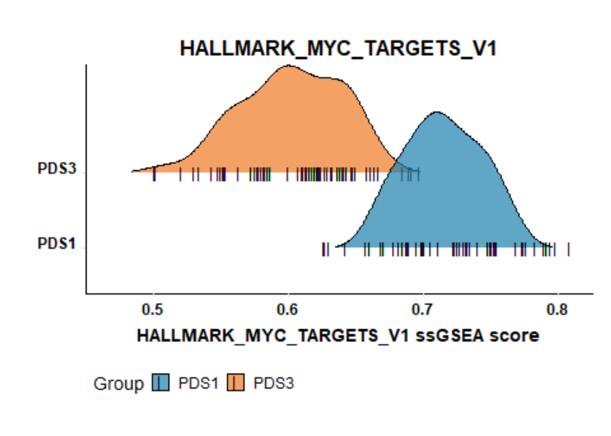

```r
ggdraw() +
  draw_image(here::here("data/example_run/example_result", "output6.png"))
```

#### 7. Single sample GSEA Histogram:

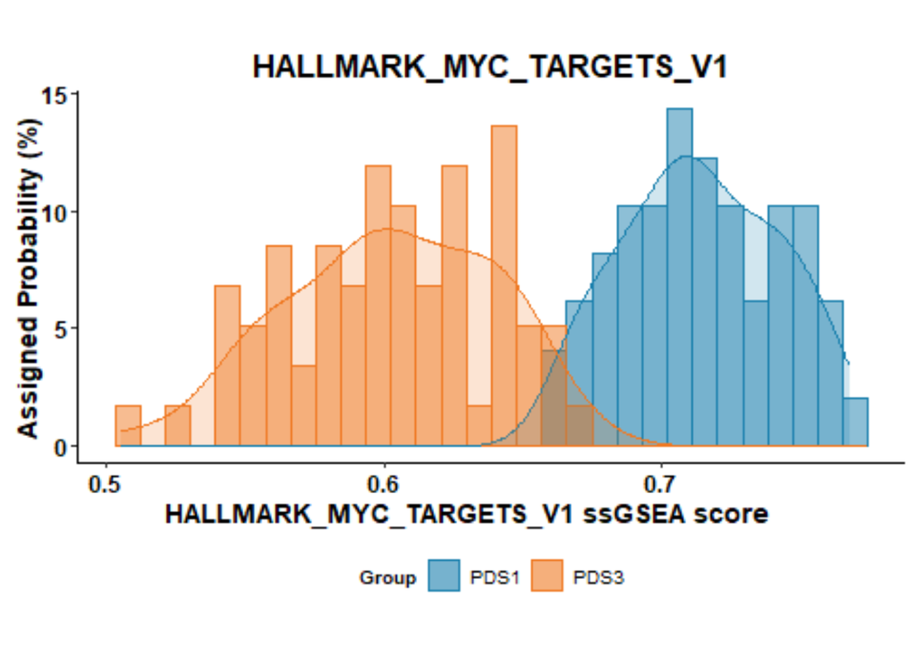

```r
ggdraw() +
  draw_image(here::here("data/example_run/example_result", "output7.png"))
```

#### 8. Single sample GSEA ROC plot:

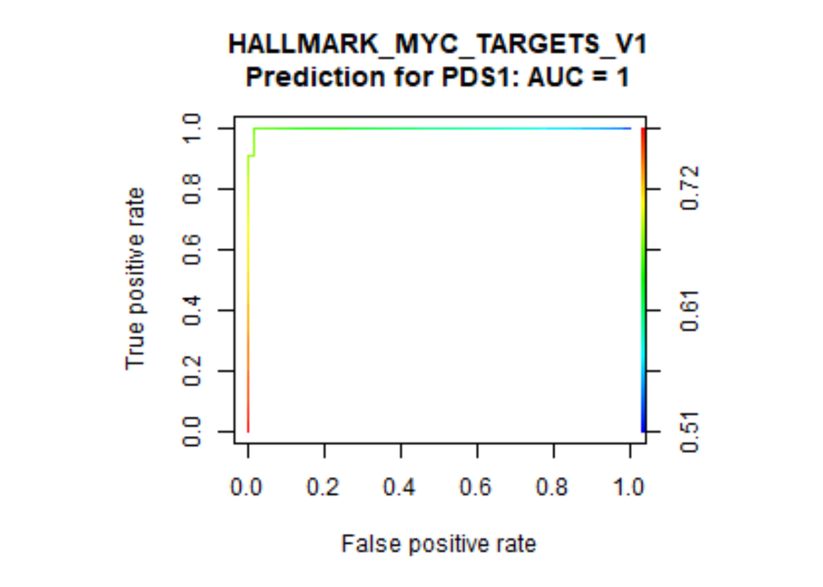

```r
ggdraw() +
  draw_image(here::here("data/example_run/example_result", "output8.png"))
```

#### 9. Single sample GSEA Optimum Cutoff Labels (for Waterfall plots):

```r
reactable(head(res1[["SingleSample_OptimumCutoff_Labels"]])[1:5,1:5])
```

|  | HALLMARK_ADIPOGENESIS | HALLMARK_ALLOGRAFT_REJECTION | HALLMARK_ANDROGEN_RESPONSE | HALLMARK_ANGIOGENESIS | HALLMARK_APOPTOSIS |
| --- | --- | --- | --- | --- | --- |
| R01251005N | Above | Above | Above | Above | Above |
| R0125F008N | Above | Above | Above | Above | Above |
| R0125F011R | Above | Above | Above | Above | Above |
| R0125F013R | Above | Above | Above | Above | Above |
| R0125F020N | Above | Above | Above | Above | Above |

#### 10. Single sample Waterfallplot:

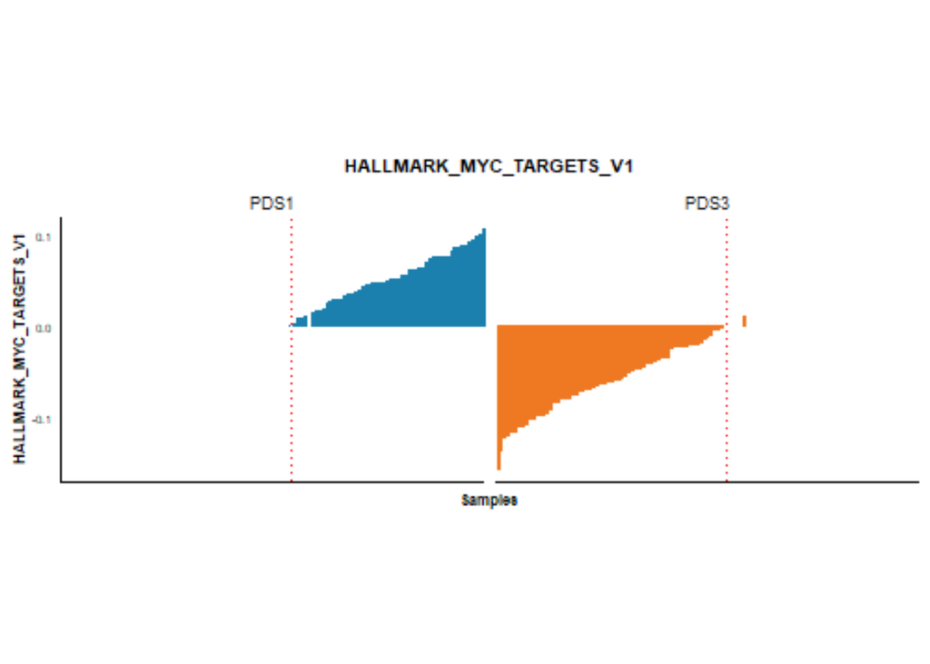

```r
ggdraw() +
  draw_image(here::here("data/example_run/example_result", "output10.png"))
```

### Session End

```r
devtools::session_info()
## ─ Session info ───────────────────────────────────────────────────────────────
##  setting  value
##  version  R version 4.4.1 (2024-06-14 ucrt)
##  os       Windows 11 x64 (build 22631)
##  system   x86_64, mingw32
##  ui       RTerm
##  language (EN)
##  collate  English_United Kingdom.utf8
##  ctype    English_United Kingdom.utf8
##  tz       Europe/London
##  date     2024-10-25
##  pandoc   3.2 @ C:/Program Files/RStudio/resources/app/bin/quarto/bin/tools/ (via rmarkdown)
##
## ─ Packages ───────────────────────────────────────────────────────────────────
##  package              * version     date (UTC) lib source
##  abind                  1.4-5       2016-07-21 [1] CRAN (R 4.4.0)
##  annotate               1.82.0      2024-05-10 [1] Bioconductor 3.19 (R 4.4.0)
##  AnnotationDbi          1.66.0      2024-05-01 [1] Bioconductor 3.19 (R 4.4.0)
##  ape                    5.8         2024-04-11 [1] CRAN (R 4.4.1)
##  aplot                  0.2.3       2024-06-17 [1] CRAN (R 4.4.1)
##  AUCell                 1.26.0      2024-05-01 [1] Bioconductor 3.19 (R 4.4.0)
##  babelgene              22.9        2022-09-29 [1] CRAN (R 4.4.0)
##  backports              1.5.0       2024-05-23 [1] CRAN (R 4.4.0)
##  beachmat               2.18.1      2024-02-14 [1] Bioconductor 3.18 (R 4.4.1)
##  beeswarm               0.4.0       2021-06-01 [1] CRAN (R 4.4.0)
##  Biobase                2.62.0      2023-10-24 [1] Bioconductor
##  BiocGenerics           0.50.0      2024-05-01 [1] Bioconductor 3.19 (R 4.4.0)
##  BiocNeighbors          1.22.0      2024-05-01 [1] Bioconductor 3.19 (R 4.4.0)
##  BiocParallel           1.36.0      2023-10-24 [1] Bioconductor
##  BiocSingular           1.18.0      2023-10-24 [1] Bioconductor
##  Biostrings             2.70.3      2024-03-13 [1] Bioconductor 3.18 (R 4.4.1)
##  bit                    4.0.5       2022-11-15 [1] CRAN (R 4.4.0)
##  bit64                  4.0.5       2020-08-30 [1] CRAN (R 4.4.0)
##  bitops                 1.0-7       2021-04-24 [1] CRAN (R 4.4.0)
##  blob                   1.2.4       2023-03-17 [1] CRAN (R 4.4.0)
##  broom                  1.0.6       2024-05-17 [1] CRAN (R 4.4.0)
##  bslib                  0.7.0       2024-03-29 [1] CRAN (R 4.4.0)
##  cachem                 1.1.0       2024-05-16 [1] CRAN (R 4.4.0)
##  car                    3.1-2       2023-03-30 [1] CRAN (R 4.4.1)
##  carData                3.0-5       2022-01-06 [1] CRAN (R 4.4.1)
##  caret                * 6.0-94      2023-03-21 [1] CRAN (R 4.4.0)
##  circlize             * 0.4.16      2024-02-20 [1] CRAN (R 4.4.0)
##  class                  7.3-22      2023-05-03 [2] CRAN (R 4.4.1)
##  cli                    3.6.2       2023-12-11 [1] CRAN (R 4.4.0)
##  clue                   0.3-65      2023-09-23 [1] CRAN (R 4.4.1)
##  cluster                2.1.6       2023-12-01 [2] CRAN (R 4.4.1)
##  codetools              0.2-20      2024-03-31 [2] CRAN (R 4.4.1)
##  colorspace             2.1-0       2023-01-23 [1] CRAN (R 4.4.0)
##  ComplexHeatmap       * 2.20.0      2024-05-01 [1] Bioconductor 3.19 (R 4.4.0)
##  cowplot              * 1.1.3       2024-01-22 [1] CRAN (R 4.4.0)
##  crayon                 1.5.3       2024-06-20 [1] CRAN (R 4.4.1)
##  crosstalk              1.2.1       2023-11-23 [1] CRAN (R 4.4.0)
##  cutpointr            * 1.1.2       2022-04-13 [1] CRAN (R 4.4.1)
##  data.table           * 1.15.4      2024-03-30 [1] CRAN (R 4.4.0)
##  DBI                    1.2.3       2024-06-02 [1] CRAN (R 4.4.0)
##  DelayedArray           0.28.0      2023-10-24 [1] Bioconductor
##  DelayedMatrixStats     1.26.0      2024-05-01 [1] Bioconductor 3.19 (R 4.4.0)
##  devtools             * 2.4.5       2022-10-11 [1] CRAN (R 4.4.0)
##  digest                 0.6.35      2024-03-11 [1] CRAN (R 4.4.0)
##  distributional         0.4.0       2024-02-07 [1] CRAN (R 4.4.0)
##  doParallel             1.0.17      2022-02-07 [1] CRAN (R 4.4.1)
##  doRNG                * 1.8.6       2023-01-16 [1] CRAN (R 4.4.1)
##  DOSE                 * 3.30.5      2024-09-01 [1] Bioconductor 3.19 (R 4.4.1)
##  dotCall64              1.1-1       2023-11-28 [1] CRAN (R 4.4.0)
##  dplyr                * 1.1.4       2023-11-17 [1] CRAN (R 4.4.0)
##  easyGgplot2          * 1.0.0.9000  2024-10-18 [1] Github (kassambara/easyGgplot2@cb017c1)
##  ellipsis               0.3.2       2021-04-29 [1] CRAN (R 4.4.0)
##  enrichplot           * 1.24.4      2024-09-01 [1] Bioconductor 3.19 (R 4.4.1)
##  escape               * 2.0.0       2024-05-01 [1] Bioconductor 3.19 (R 4.4.0)
##  evaluate               0.24.0      2024-06-10 [1] CRAN (R 4.4.0)
##  fansi                  1.0.6       2023-12-08 [1] CRAN (R 4.4.0)
##  farver                 2.1.2       2024-05-13 [1] CRAN (R 4.4.0)
##  fastmap                1.2.0       2024-05-15 [1] CRAN (R 4.4.0)
##  fastmatch              1.1-4       2023-08-18 [1] CRAN (R 4.4.0)
##  fgsea                * 1.30.0      2024-05-01 [1] Bioconductor 3.19 (R 4.4.0)
##  forcats              * 1.0.0       2023-01-29 [1] CRAN (R 4.4.0)
##  foreach              * 1.5.2       2022-02-02 [1] CRAN (R 4.4.0)
##  formatR                1.14        2023-01-17 [1] CRAN (R 4.4.0)
##  fs                     1.6.4       2024-04-25 [1] CRAN (R 4.4.0)
##  future                 1.33.2      2024-03-26 [1] CRAN (R 4.4.0)
##  future.apply           1.11.2      2024-03-28 [1] CRAN (R 4.4.0)
##  generics               0.1.3       2022-07-05 [1] CRAN (R 4.4.0)
##  GenomeInfoDb           1.40.1      2024-06-16 [1] Bioconductor 3.19 (R 4.4.0)
##  GenomeInfoDbData       1.2.12      2024-06-19 [1] Bioconductor
##  GenomicRanges          1.56.2      2024-10-09 [1] Bioconductor 3.19 (R 4.4.1)
##  GetoptLong             1.0.5       2020-12-15 [1] CRAN (R 4.4.1)
##  ggalluvial           * 0.12.5      2023-02-22 [1] CRAN (R 4.4.1)
##  ggbeeswarm           * 0.7.2       2023-04-29 [1] CRAN (R 4.4.0)
##  ggdist                 3.3.2       2024-03-05 [1] CRAN (R 4.4.0)
##  ggforce                0.4.2       2024-02-19 [1] CRAN (R 4.4.1)
##  ggfun                  0.1.6       2024-08-28 [1] CRAN (R 4.4.1)
##  ggplot2              * 3.5.1       2024-04-23 [1] CRAN (R 4.4.0)
##  ggplotify              0.1.2       2023-08-09 [1] CRAN (R 4.4.1)
##  ggpointdensity         0.1.0       2019-08-28 [1] CRAN (R 4.4.0)
##  ggpubr               * 0.6.0       2023-02-10 [1] CRAN (R 4.4.1)
##  ggraph                 2.2.1       2024-03-07 [1] CRAN (R 4.4.1)
##  ggrepel                0.9.5       2024-01-10 [1] CRAN (R 4.4.0)
##  ggridges             * 0.5.6       2024-01-23 [1] CRAN (R 4.4.0)
##  ggsignif               0.6.4       2022-10-13 [1] CRAN (R 4.4.1)
##  ggtree                 3.12.0      2024-05-01 [1] Bioconductor 3.19 (R 4.4.0)
##  GlobalOptions          0.1.2       2020-06-10 [1] CRAN (R 4.4.0)
##  globals                0.16.3      2024-03-08 [1] CRAN (R 4.4.0)
##  glue                   1.7.0       2024-01-09 [1] CRAN (R 4.4.0)
##  GO.db                  3.19.1      2024-10-16 [1] Bioconductor
##  GOSemSim               2.30.2      2024-08-21 [1] Bioconductor 3.19 (R 4.4.1)
##  gower                  1.0.1       2022-12-22 [1] CRAN (R 4.4.0)
##  graph                  1.80.0      2023-10-24 [1] Bioconductor
##  graphlayouts           1.2.0       2024-09-24 [1] CRAN (R 4.4.1)
##  gridExtra            * 2.3         2017-09-09 [1] CRAN (R 4.4.0)
##  gridGraphics           0.5-1       2020-12-13 [1] CRAN (R 4.4.1)
##  GSEABase               1.66.0      2024-05-01 [1] Bioconductor 3.19 (R 4.4.0)
##  GSVA                 * 1.50.5      2024-04-15 [1] Bioconductor 3.18 (R 4.4.1)
##  gtable                 0.3.5       2024-04-22 [1] CRAN (R 4.4.0)
##  hardhat                1.4.0       2024-06-02 [1] CRAN (R 4.4.0)
##  HDF5Array              1.30.1      2024-02-14 [1] Bioconductor 3.18 (R 4.4.1)
##  here                   1.0.1       2020-12-13 [1] CRAN (R 4.4.0)
##  highr                  0.11        2024-05-26 [1] CRAN (R 4.4.0)
##  hms                    1.1.3       2023-03-21 [1] CRAN (R 4.4.0)
##  htmltools              0.5.8.1     2024-04-04 [1] CRAN (R 4.4.0)
##  htmlwidgets            1.6.4       2023-12-06 [1] CRAN (R 4.4.0)
##  httpuv                 1.6.15      2024-03-26 [1] CRAN (R 4.4.0)
##  httr                   1.4.7       2023-08-15 [1] CRAN (R 4.4.0)
##  httr2                  1.0.1       2024-04-01 [1] CRAN (R 4.4.0)
##  igraph                 2.0.3       2024-03-13 [1] CRAN (R 4.4.0)
##  ipred                  0.9-14      2023-03-09 [1] CRAN (R 4.4.0)
##  IRanges                2.38.1      2024-07-03 [1] Bioconductor 3.19 (R 4.4.1)
##  irlba                  2.3.5.1     2022-10-03 [1] CRAN (R 4.4.0)
##  iterators              1.0.14      2022-02-05 [1] CRAN (R 4.4.0)
##  jquerylib              0.1.4       2021-04-26 [1] CRAN (R 4.4.0)
##  jsonlite               1.8.8       2023-12-04 [1] CRAN (R 4.4.0)
##  KEGGREST               1.44.0      2024-05-01 [1] Bioconductor 3.19 (R 4.4.0)
##  knitr                  1.47        2024-05-29 [1] CRAN (R 4.4.0)
##  labeling               0.4.3       2023-08-29 [1] CRAN (R 4.4.0)
##  later                  1.3.2       2023-12-06 [1] CRAN (R 4.4.0)
##  lattice              * 0.22-6      2024-03-20 [2] CRAN (R 4.4.1)
##  lava                   1.8.0       2024-03-05 [1] CRAN (R 4.4.0)
##  lazyeval               0.2.2       2019-03-15 [1] CRAN (R 4.4.0)
##  lifecycle              1.0.4       2023-11-07 [1] CRAN (R 4.4.0)
##  limma                * 3.60.3      2024-06-16 [1] Bioconductor 3.19 (R 4.4.0)
##  listenv                0.9.1       2024-01-29 [1] CRAN (R 4.4.0)
##  lubridate            * 1.9.3       2023-09-27 [1] CRAN (R 4.4.0)
##  magick                 2.8.3       2024-02-18 [1] CRAN (R 4.4.0)
##  magrittr               2.0.3       2022-03-30 [1] CRAN (R 4.4.0)
##  MASS                   7.3-60.2    2024-04-26 [2] CRAN (R 4.4.1)
##  Matrix                 1.7-0       2024-04-26 [2] CRAN (R 4.4.1)
##  MatrixGenerics         1.16.0      2024-05-01 [1] Bioconductor 3.19 (R 4.4.0)
##  matrixStats            1.3.0       2024-04-11 [1] CRAN (R 4.4.0)
##  memoise                2.0.1       2021-11-26 [1] CRAN (R 4.4.0)
##  mime                   0.12        2021-09-28 [1] CRAN (R 4.4.0)
##  miniUI                 0.1.1.1     2018-05-18 [1] CRAN (R 4.4.0)
##  ModelMetrics           1.2.2.2     2020-03-17 [1] CRAN (R 4.4.0)
##  msigdbr              * 7.5.1       2022-03-30 [1] CRAN (R 4.4.0)
##  munsell                0.5.1       2024-04-01 [1] CRAN (R 4.4.0)
##  nlme                   3.1-164     2023-11-27 [2] CRAN (R 4.4.1)
##  nnet                   7.3-19      2023-05-03 [2] CRAN (R 4.4.1)
##  parallelly             1.37.1      2024-02-29 [1] CRAN (R 4.4.0)
##  patchwork              1.2.0       2024-01-08 [1] CRAN (R 4.4.0)
##  pillar                 1.9.0       2023-03-22 [1] CRAN (R 4.4.0)
##  pkgbuild               1.4.4       2024-03-17 [1] CRAN (R 4.4.0)
##  pkgconfig              2.0.3       2019-09-22 [1] CRAN (R 4.4.0)
##  pkgload                1.3.4       2024-01-16 [1] CRAN (R 4.4.0)
##  plyr                   1.8.9       2023-10-02 [1] CRAN (R 4.4.0)
##  png                    0.1-8       2022-11-29 [1] CRAN (R 4.4.0)
##  polyclip               1.10-6      2023-09-27 [1] CRAN (R 4.4.0)
##  pROC                 * 1.18.5      2023-11-01 [1] CRAN (R 4.4.0)
##  prodlim                2023.08.28  2023-08-28 [1] CRAN (R 4.4.0)
##  profvis                0.3.8       2023-05-02 [1] CRAN (R 4.4.0)
##  progressr              0.14.0      2023-08-10 [1] CRAN (R 4.4.0)
##  promises               1.3.0       2024-04-05 [1] CRAN (R 4.4.0)
##  purrr                * 1.0.2       2023-08-10 [1] CRAN (R 4.4.0)
##  qvalue                 2.36.0      2024-05-01 [1] Bioconductor 3.19 (R 4.4.0)
##  R.methodsS3            1.8.2       2022-06-13 [1] CRAN (R 4.4.0)
##  R.oo                   1.26.0      2024-01-24 [1] CRAN (R 4.4.0)
##  R.utils                2.12.3      2023-11-18 [1] CRAN (R 4.4.0)
##  R6                     2.5.1       2021-08-19 [1] CRAN (R 4.4.0)
```

```r
##  randomForest         * 4.7-1.1     2022-05-23 [1] CRAN (R 4.4.1)
##  rappdirs               0.3.3       2021-01-31 [1] CRAN (R 4.4.0)
##  RColorBrewer         * 1.1-3       2022-04-03 [1] CRAN (R 4.4.0)
##  Rcpp                   1.0.12      2024-01-09 [1] CRAN (R 4.4.0)
##  RCurl                  1.98-1.14   2024-01-09 [1] CRAN (R 4.4.0)
##  reactable            * 0.4.4       2023-03-12 [1] CRAN (R 4.4.1)
##  reactR                 0.6.1       2024-09-14 [1] CRAN (R 4.4.1)
##  readr                * 2.1.5       2024-01-10 [1] CRAN (R 4.4.0)
##  recipes                1.0.10      2024-02-18 [1] CRAN (R 4.4.0)
##  remotes                2.5.0       2024-03-17 [1] CRAN (R 4.4.0)
##  reshape2             * 1.4.4       2020-04-09 [1] CRAN (R 4.4.0)
##  rhdf5                  2.46.1      2023-11-29 [1] Bioconductor 3.18 (R 4.4.1)
##  rhdf5filters           1.14.1      2023-11-06 [1] Bioconductor
##  Rhdf5lib               1.24.2      2024-02-07 [1] Bioconductor 3.18 (R 4.4.1)
##  rjson                  0.2.21      2022-01-09 [1] CRAN (R 4.4.0)
##  rlang                  1.1.4       2024-06-04 [1] CRAN (R 4.4.0)
##  rmarkdown              2.27        2024-05-17 [1] CRAN (R 4.4.0)
##  rngtools             * 1.5.2       2021-09-20 [1] CRAN (R 4.4.1)
##  ROCR                 * 1.0-11      2020-05-02 [1] CRAN (R 4.4.0)
##  rpart                  4.1.23      2023-12-05 [2] CRAN (R 4.4.1)
##  rprojroot              2.0.4       2023-11-05 [1] CRAN (R 4.4.0)
##  RSQLite                2.3.7       2024-05-27 [1] CRAN (R 4.4.0)
##  rstatix                0.7.2       2023-02-01 [1] CRAN (R 4.4.1)
##  rstudioapi             0.16.0      2024-03-24 [1] CRAN (R 4.4.0)
##  rsvd                   1.0.5       2021-04-16 [1] CRAN (R 4.4.0)
##  S4Arrays               1.2.1       2024-03-04 [1] Bioconductor 3.18 (R 4.4.1)
##  S4Vectors              0.40.2      2023-11-23 [1] Bioconductor 3.18 (R 4.4.1)
##  sass                   0.4.9       2024-03-15 [1] CRAN (R 4.4.0)
##  ScaledMatrix           1.12.0      2024-05-01 [1] Bioconductor 3.19 (R 4.4.0)
##  scales                 1.3.0       2023-11-28 [1] CRAN (R 4.4.0)
##  scatterpie             0.2.4       2024-08-28 [1] CRAN (R 4.4.1)
##  sessioninfo            1.2.2       2021-12-06 [1] CRAN (R 4.4.0)
##  SeuratObject           5.0.2       2024-05-08 [1] CRAN (R 4.4.0)
##  shadowtext             0.1.4       2024-07-18 [1] CRAN (R 4.4.1)
##  shape                  1.4.6.1     2024-02-23 [1] CRAN (R 4.4.0)
##  shiny                  1.8.1.1     2024-04-02 [1] CRAN (R 4.4.0)
##  SingleCellExperiment   1.26.0      2024-05-01 [1] Bioconductor 3.19 (R 4.4.0)
##  snow                   0.4-4       2021-10-27 [1] CRAN (R 4.4.0)
##  sp                     2.1-4       2024-04-30 [1] CRAN (R 4.4.0)
##  spam                   2.10-0      2023-10-23 [1] CRAN (R 4.4.0)
##  SparseArray            1.2.4       2024-02-11 [1] Bioconductor 3.18 (R 4.4.1)
##  sparseMatrixStats      1.14.0      2023-10-24 [1] Bioconductor
##  statmod                1.5.0       2023-01-06 [1] CRAN (R 4.4.0)
##  stringi                1.8.4       2024-05-06 [1] CRAN (R 4.4.0)
##  stringr              * 1.5.1       2023-11-14 [1] CRAN (R 4.4.0)
##  SummarizedExperiment   1.34.0      2024-05-01 [1] Bioconductor 3.19 (R 4.4.0)
##  survival               3.6-4       2024-04-24 [2] CRAN (R 4.4.1)
##  tibble               * 3.2.1       2023-03-20 [1] CRAN (R 4.4.0)
##  tidygraph              1.3.1       2024-01-30 [1] CRAN (R 4.4.1)
##  tidyr                * 1.3.1       2024-01-24 [1] CRAN (R 4.4.0)
##  tidyselect             1.2.1       2024-03-11 [1] CRAN (R 4.4.0)
##  tidytree               0.4.6       2023-12-12 [1] CRAN (R 4.4.1)
##  tidyverse            * 2.0.0       2023-02-22 [1] CRAN (R 4.4.0)
##  timechange             0.3.0       2024-01-18 [1] CRAN (R 4.4.0)
##  timeDate               4032.109    2023-12-14 [1] CRAN (R 4.4.0)
##  treeio                 1.28.0      2024-05-01 [1] Bioconductor 3.19 (R 4.4.0)
##  tweenr                 2.0.3       2024-02-26 [1] CRAN (R 4.4.1)
##  tzdb                   0.4.0       2023-05-12 [1] CRAN (R 4.4.0)
##  UCell                  2.8.0       2024-05-01 [1] Bioconductor 3.19 (R 4.4.0)
##  UCSC.utils             1.0.0       2024-05-01 [1] Bioconductor 3.19 (R 4.4.0)
##  urlchecker             1.0.1       2021-11-30 [1] CRAN (R 4.4.0)
##  usethis              * 2.2.3       2024-02-19 [1] CRAN (R 4.4.0)
##  utf8                   1.2.4       2023-10-22 [1] CRAN (R 4.4.0)
##  vctrs                  0.6.5       2023-12-01 [1] CRAN (R 4.4.0)
##  vipor                  0.4.7       2023-12-18 [1] CRAN (R 4.4.0)
##  viridis                0.6.5       2024-01-29 [1] CRAN (R 4.4.1)
##  viridisLite            0.4.2       2023-05-02 [1] CRAN (R 4.4.0)
##  waterfalls           * 1.0.0       2022-11-20 [1] CRAN (R 4.4.1)
##  withr                  3.0.1       2024-07-31 [1] CRAN (R 4.4.1)
##  xfun                   0.45        2024-06-16 [1] CRAN (R 4.4.1)
##  XML                    3.99-0.16.1 2024-01-22 [1] CRAN (R 4.4.0)
##  xtable                 1.8-4       2019-04-21 [1] CRAN (R 4.4.0)
##  XVector                0.42.0      2023-10-24 [1] Bioconductor
##  yaml                   2.3.8       2023-12-11 [1] CRAN (R 4.4.0)
##  yulab.utils            0.1.7       2024-08-26 [1] CRAN (R 4.4.1)
##  zlibbioc               1.48.2      2024-03-13 [1] Bioconductor 3.18 (R 4.4.1)
##
##  [1] C:/Users/3057008/AppData/Local/R/win-library/4.4
##  [2] C:/Program Files/R/R-4.4.1/library
##
## ──────────────────────────────────────────────────────────────────────────────
```